# Scraping data from Twitter’s REST API

Pablo Barbera

August 2, 2017

### Scraping web data from Twitter

#### Collecting data from Twitter’s REST API

It is possible to download recent tweets, but only up those less than 7 days old, and in some cases not all of them. We will use the `netdemR` package for this (and the other functions that scrape Twitter’s REST API).

```r
library(netdemR)
library(streamR)
searchTweets(q=c("mcconell", "mccain"),
  filename="senator-tweets.json",
  n=1000, until="2017-07-30",
  oauth_folder="../credentials")
```

```
## 100 tweets. Max id: 891445335234453504
```

```
## 178 hits left
```

```
## 200 tweets. Max id: 891294647305347072
```

```
## 177 hits left
```

```
## 300 tweets. Max id: 891281645373984768
```

```
## 176 hits left
```

```
## 400 tweets. Max id: 891034587585032192
```

```
## 175 hits left
```

```
## 500 tweets. Max id: 890919249757298688
```

```
## 174 hits left
```

```
## 600 tweets. Max id: 890817610996080640
```

```
## 173 hits left
```

```
## 700 tweets. Max id: 890811430835896320
```

```
## 172 hits left
```

```
## 800 tweets. Max id: 890809553905786880
```

```
## 171 hits left
```

```
## 900 tweets. Max id: 890699258701262848
```

```
## 170 hits left
```

```
## 1000 tweets. Max id: 890033272696209408
```

```r
tweets <- parseTweets("senator-tweets.json")
```

```
## 1000 tweets have been parsed.
```

What are the most popular hashtags?

```r
library(stringr)
ht <- str_extract_all(tweets$text, "#(\\d|\\w)+")
ht <- unlist(ht)
head(sort(table(ht), decreasing = TRUE))
```

```
## ht
## #SkinnyRepeal       #google          #ACA     #mcconell     #McConell
##            19             7             6             6             6
## #skinnyrepeal
##             6
```

You can check the documentation about the options for string search [here](https://dev.twitter.com/rest/public/search).

This is how you would extract information from user profiles:

```r
wh <- c("realDonaldTrump", "POTUS", "VP", "FLOTUS")
users <- getUsersBatch(screen_names=wh,
                       oauth_folder="../credentials")
```

```
## 1--4 users left
```

```r
str(users)
```

```
## 'data.frame':    4 obs. of  14 variables:
##  $ id_str           : chr  "25073877" "822215679726100480" "818876014390603776" "818910970567344128"
##  $ screen_name      : chr  "realDonaldTrump" "POTUS" "FLOTUS" "VP"
##  $ name             : chr  "Donald J. Trump" "President Trump" "Melania Trump" "Vice President Pence"
##  $ description      : chr  "45th President of the United States of America" "45th President of the United States of America, @realDonaldTrump. Tweets archived: https://t.co/eVVzoBb3Zr" "This account is run by the Office of First Lady Melania Trump. Tweets may be archived. More at https://t.co/eVV…
##  $ followers_count  : int  35035138 19676841 7908612 4083400
##  $ statuses_count   : int  35426 953 104 1862
##  $ friends_count    : int  45 42 4 6
##  $ created_at       : chr  "Wed Mar 18 13:46:38 +0000 2009" "Thu Jan 19 22:54:28 +0000 2017" "Tue Jan 10 17:43:50 +0000 2017" "Tue Jan 10 20:02:44 +0000 2017"
##  $ location         : chr  "Washington, DC" "Washington, D.C." "Washington, D.C." "Washington, D.C."
##  $ lang             : chr  "en" "en" "en" "en"
##  $ time_zone        : chr  "Eastern Time (US & Canada)" "Eastern Time (US & Canada)" "Eastern Time (US & Canada)" "Eastern Time (US & Canada)"
##  $ status.id_str    : chr  "892383242535481344" "890977634972307456" "892076805674455042" "892551283281932288"
##  $ status.created_at: chr  "Tue Aug 01 13:55:19 +0000 2017" "Fri Jul 28 16:49:56 +0000 2017" "Mon Jul 31 17:37:39 +0000 2017" "Wed Aug 02 01:03:03 +0000 2017"
##  $ status.text      : chr  "Only the Fake News Media and Trump enemies want me to stop using Social Media (110 million people). Only way fo"| __truncated__ "RT @realDonaldTrump: Departing for Long Island now. An area under siege from #MS13 gang members. We will not re"| __truncated__ "Thank you t…
```

Which of these has the most followers?

```r
users[which.max(users$followers_count),]
```

```
##     id_str     screen_name            name
## 1 25073877 realDonaldTrump Donald J. Trump
##                                      description followers_count
## 1 45th President of the United States of America        35035138
##   statuses_count friends_count                     created_at
## 1          35426            45 Wed Mar 18 13:46:38 +0000 2009
##         location lang                  time_zone      status.id_str
## 1 Washington, DC   en Eastern Time (US & Canada) 892383242535481344
##                status.created_at
## 1 Tue Aug 01 13:55:19 +0000 2017
##                                                                                                                                 status.text
## 1 Only the Fake News Media and Trump enemies want me to stop using Social Media (110 million people). Only way for me to get the truth out!
```

```r
users$screen_name[which.max(users$followers_count)]
```

```
## [1] "realDonaldTrump"
```

Download up to 3,200 recent tweets from a Twitter account:

```r
getTimeline(filename="realDonaldTrump.json", screen_name="realDonaldTrump",
    n=1000, oauth_folder="../credentials")
```

```
## 200 tweets. Max id: 883444736849305600
```

```
## 898 hits left
```

```
## 400 tweets. Max id: 873878061778907137
```

```
## 897 hits left
```

```
## 600 tweets. Max id: 859143061678501892
```

```
## 896 hits left
```

```
## 800 tweets. Max id: 844536536930619393
```

```
## 895 hits left
```

```
## 1000 tweets. Max id: 829299566344359936
```

What are the most common hashtags?

```r
tweets <- parseTweets("realDonaldTrump.json")
```

```
## 1000 tweets have been parsed.
```

```r
ht <- str_extract_all(tweets$text, "#(\\d|\\w)+")
ht <- unlist(ht)
head(sort(table(ht), decreasing = TRUE))
```

```
## ht
##         #MAGA        #ICYMI          #USA     #FakeNews #AmericaFirst
##            15            11            10             9             8
##    #Obamacare
##             6
```

Download friends and followers:

```r
followers <- getFollowers("ecpr",
    oauth_folder="../credentials")
```

```
## ../credentials/twitter-token.Rdata
```

```
## 15 API calls left
```

```
## 5000 followers. Next cursor: 1505108097996709997
```

```
## 14 API calls left
```

```
## 10000 followers. Next cursor: 1370131470074099998
```

```
## 13 API calls left
```

```
## 10339 followers. Next cursor: 0
```

```
## 12 API calls left
```

```r
friends <- getFriends("ecpr",
    oauth_folder="../credentials")
```

```
## ../credentials/twitter-token.Rdata
```

```
## 15 API calls left
```

```
## 981 friends. Next cursor: 0
```

```
## 14 API calls left
```

What are the most common words that friends of the ECPR Twitter account use to describe themselves on Twitter?

```r
# extract profile descriptions
users <- getUsersBatch(ids=friends, oauth_folder="../credentials")
```

```
## 1--981 users left
```

```
## 2--881 users left
```

```
## 3--781 users left
```

```
## 4--681 users left
```

```
## 5--581 users left
```

```
## 6--481 users left
```

```
## 7--381 users left
```

```
## 8--281 users left
```

```
## 9--181 users left
```

```
## 10--81 users left
```

```r
# create table with frequency of word use
library(quanteda)
```

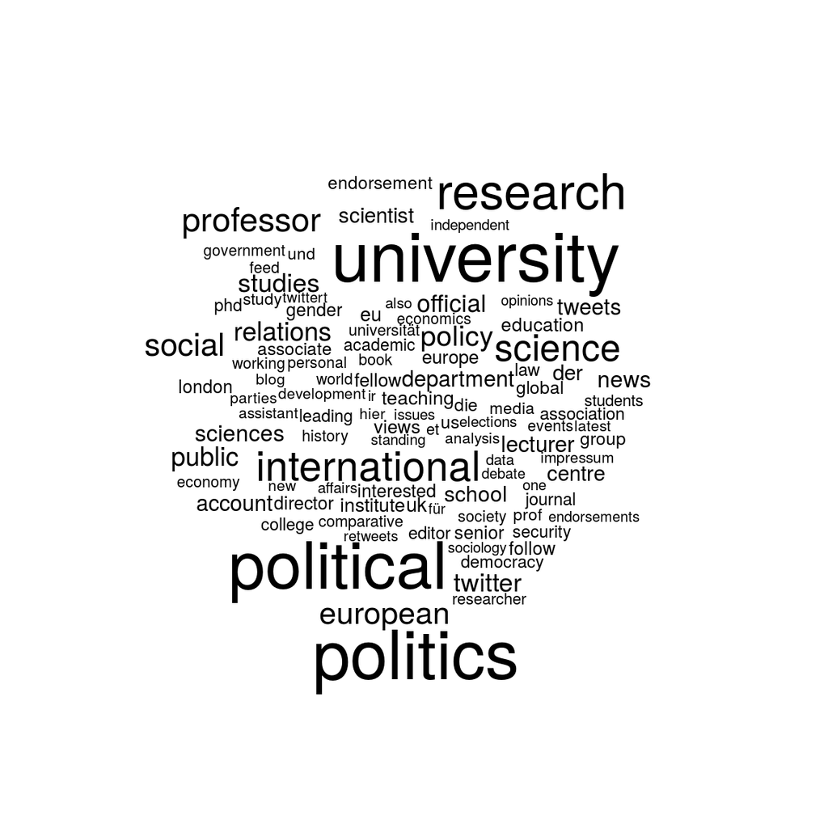

```r
tw <- corpus(users$description[users$description!=""])
dfm <- dfm(tw, remove=c(stopwords("english"), stopwords("spanish"),
                                 "t.co", "https", "rt", "rts", "http"),
           remove_punct=TRUE)
# create wordcloud
par(mar=c(0,0,0,0))
textplot_wordcloud(dfm, rot.per=0, scale=c(3, .50), max.words=100)
```

The REST API offers also a long list of other endpoints that could be of use at some point, depending on your research interests.

1. You can search users related to specific keywords:

```r
users <- searchUsers(q="ecpr", count=100, oauth_folder="../credentials")
```

```
## ../credentials/twitter-token.Rdata
```

2. If you know the ID of the tweets, you can download it directly from the API. This is useful because tweets cannot be redistributed as part of the replication materials of a published paper, but the list of tweet IDs can be shared:

```r
# Downloading tweets when you know the ID
getStatuses(ids=c("474134260149157888", "266038556504494082"), filename="old-tweets.json",
            oauth_folder="../credentials")
```

```
## ../credentials/twitter-token.Rdata
```

```
## 900 API calls left
```

```
## 899 API calls left
```

```r
parseTweets("old-tweets.json")
```

```
## 2 tweets have been parsed.
```

```
##                                                             text
## 1 Are you allowed to impeach a president for gross incompetence?
## 2           The electoral college is a disaster for a democracy.
##   retweet_count favorited truncated             id_str
## 1             0     FALSE     FALSE 474134260149157888
## 2             0     FALSE     FALSE 266038556504494082
##   in_reply_to_screen_name
## 1                      NA
## 2                      NA
##                                                                                 source
## 1 <a href="http://twitter.com/download/android" rel="nofollow">Twitter for Android</a>
## 2                   <a href="http://twitter.com" rel="nofollow">Twitter Web Client</a>
##   retweeted                     created_at in_reply_to_status_id_str
## 1     FALSE Wed Jun 04 10:23:11 +0000 2014                        NA
## 2     FALSE Wed Nov 07 04:45:09 +0000 2012                        NA
##   in_reply_to_user_id_str lang listed_count verified       location
## 1                      NA   en        73836     TRUE Washington, DC
## 2                      NA   en        73836     TRUE Washington, DC
##   user_id_str                                    description geo_enabled
## 1    25073877 45th President of the United States of America        TRUE
## 2    25073877 45th President of the United States of America        TRUE
##                  user_created_at statuses_count followers_count
## 1 Wed Mar 18 13:46:38 +0000 2009          35426        35035148
## 2 Wed Mar 18 13:46:38 +0000 2009          35426        35035148
##   favourites_count protected user_url            name
## 1               12     FALSE       NA Donald J. Trump
## 2               12     FALSE       NA Donald J. Trump
##                    time_zone user_lang utc_offset friends_count
## 1 Eastern Time (US & Canada)        en     -14400            45
## 2 Eastern Time (US & Canada)        en     -14400            45
##       screen_name country_code country place_type full_name place_name
## 1 realDonaldTrump           NA      NA         NA        NA         NA
## 2 realDonaldTrump           NA      NA         NA        NA         NA
##   place_id place_lat place_lon lat lon expanded_url url
## 1       NA       NaN       NaN  NA  NA           NA  NA
## 2       NA       NaN       NaN  NA  NA           NA  NA
```

3. Lists of Twitter users, compiled by other users, are also accessible through the API.

```r
# download user information from a list
MCs <- getList(list_name="new-members-of-congress",
               screen_name="cspan", oauth_folder="../credentials")
```

```
## ../credentials/twitter-token.Rdata
```

```
## 900 API calls left
```

```
## 20 users in list. Next cursor: 5427698142933319684
```

```
## 899 API calls left
```

```
## 40 users in list. Next cursor: 4611686021745187729
```

```
## 898 API calls left
```

```
## 60 users in list. Next cursor: 0
```

```
## 897 API calls left
```

```r
head(MCs)
```

```
##             id             id_str                 name     screen_name
## 1 8.272798e+17 827279765287559171    Rep. Mike Johnson  RepMikeJohnson
## 2 8.235530e+17 823552974253342721     Anthony G. Brown RepAnthonyBrown
## 3 8.171385e+17 817138492614524928             Ted Budd      RepTedBudd
## 4 8.170763e+17 817076257770835968    Adriano Espaillat    RepEspaillat
## 5 8.170502e+17 817050219007328258 Rep. Blunt Rochester   RepBRochester
## 6 8.168339e+17 816833925456789505  Nanette D. Barragán     RepBarragan
##                         location
## 1                 Washington, DC
## 2                 Washington, DC
## 3  Davie County, North Carolina
## 4 https://www.facebook.com/Congr
## 5 Delaware, USA - Washington, DC
## 6                  San Pedro, CA
##                                                                                                                                           description
```

[output cut: 20 more lines]

This is also useful if e.g. you’re interested in compiling lists of journalists, because media outlets offer these lists in their profiles.

4. List of users who retweeted a particular tweet – unfortunately, it’s limited to only 100 most recent retweets.

```r
# Download list of users who retweeted a tweet (unfortunately, only up to 100)
rts <- getRetweets(id='892147656319004672', oauth_folder="../credentials")
```

```
## ../credentials/twitter-token.Rdata
```

```
## 75 API calls left
```

```
## 87 retweeters. Next cursor: 0
```

```
## 74 API calls left
```

```r
# https://twitter.com/realDonaldTrump/status/892147656319004672
users <- getUsersBatch(ids=rts, oauth_folder="../credentials")
```

```
## 1--87 users left
```

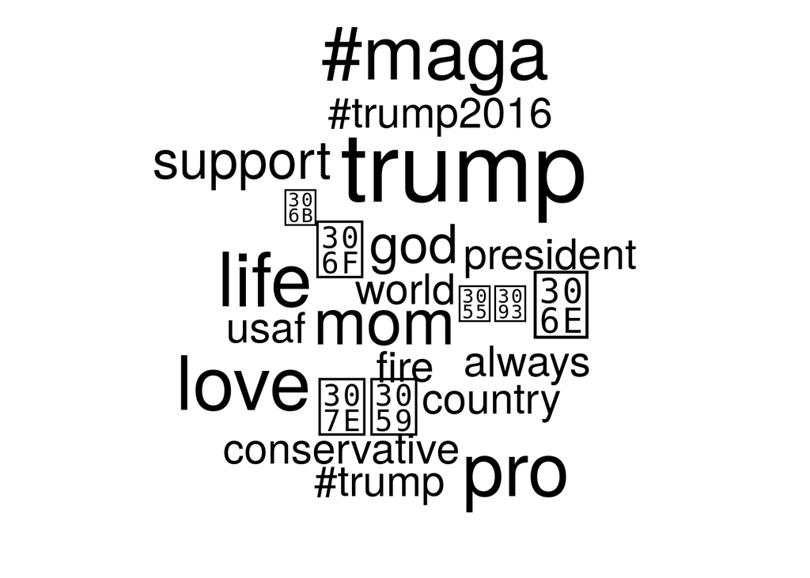

```r
# create table with frequency of word use
library(quanteda)
tw <- corpus(users$description[users$description!=""])
dfm <- dfm(tw, remove=c(stopwords("english"), stopwords("spanish"),
                                 "t.co", "https", "rt", "rts", "http"),
           remove_punct = TRUE)
# create wordcloud
par(mar=c(0,0,0,0))
textplot_wordcloud(dfm, rot.per=0, scale=c(5, .50), max.words=100)
```

5. And one final function to convert dates in their internal Twitter format to another format we could work with in R:

```r
# format Twitter dates to facilitate analysis
tweets <- parseTweets("realDonaldTrump.json")
```

```
## 1000 tweets have been parsed.
```

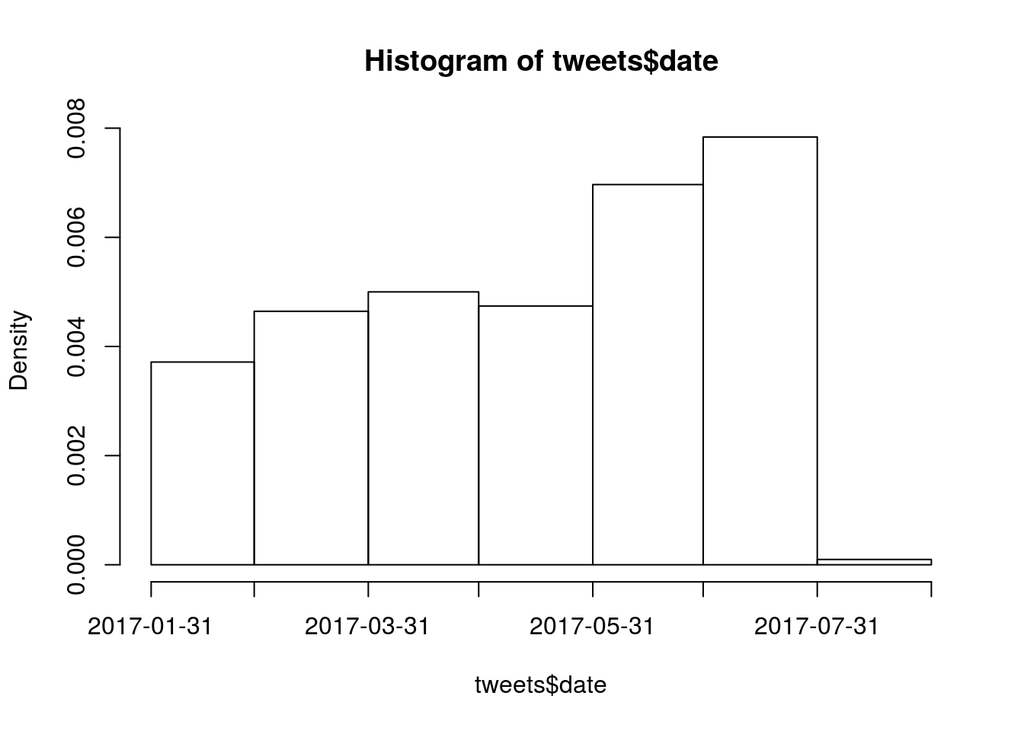

```r
tweets$date <- formatTwDate(tweets$created_at, format="date")
hist(tweets$date, breaks="month")
```